# R Notebook

```r
library(RPostgreSQL)
```

```sql
SELECT *
FROM flights
LIMIT 5;
```

| year | month | day | day_of_week | airline | flight_number | tail_number | origin_airport | destination_airport | scheduled_departure | departure_time | departure_delay | taxi_out | wheels_off | scheduled_time | elapsed_time | air_time | distance | wheels_on | taxi_in | scheduled_arrival | arrival_time | arrival_delay | diverted | cancelled | cancellation_reason | air_system_delay | security_delay | airline_delay | late_aircraft_delay | … |
| --- | --- | --- | --- | --- | --- | --- | --- | --- | --- | --- | --- | --- | --- | --- | --- | --- | --- | --- | --- | --- | --- | --- | --- | --- | --- | --- | --- | --- | --- | --- |
| 2015 | 1 | 1 | 4 | AS | 98 | N407AS | ANC | SEA | 0005 | 2354 | -11 | 21 | 0015 | 205 | 194 | 169 | 1448 | 0404 | 4 | 0430 | 0408 | -22 | 0 | 0 | NA | NA | NA | NA | NA | … |
| 2015 | 1 | 1 | 4 | AA | 2336 | N3KUAA | LAX | PBI | 0010 | 0002 | -8 | 12 | 0014 | 280 | 279 | 263 | 2330 | 0737 | 4 | 0750 | 0741 | -9 | 0 | 0 | NA | NA | NA | NA | NA | … |
| 2015 | 1 | 1 | 4 | US | 840 | N171US | SFO | CLT | 0020 | 0018 | -2 | 16 | 0034 | 286 | 293 | 266 | 2296 | 0800 | 11 | 0806 | 0811 | 5 | 0 | 0 | NA | NA | NA | NA | NA | … |
| 2015 | 1 | 1 | 4 | AA | 258 | N3HYAA | LAX | MIA | 0020 | 0015 | -5 | 15 | 0030 | 285 | 281 | 258 | 2342 | 0748 | 8 | 0805 | 0756 | -9 | 0 | 0 | NA | NA | NA | NA | NA | … |
| 2015 | 1 | 1 | 4 | AS | 135 | N527AS | SEA | ANC | 0025 | 0024 | -1 | 11 | 0035 | 235 | 215 | 199 | 1448 | 0254 | 5 | 0320 | 0259 | -21 | 0 | 0 | NA | NA | NA | NA | NA | … |

```sql
SELECT CASE WHEN CAST(LEFT(scheduled_departure, 2) AS int) >= 0 AND CAST(LEFT(scheduled_departure, 2) AS int) < 6 THEN 'Night'
  WHEN CAST(LEFT(scheduled_departure, 2) AS int) >= 6 AND CAST(LEFT(scheduled_departure, 2) AS int) < 12 THEN 'Morning'
  WHEN CAST(LEFT(scheduled_departure, 2) AS int) >= 12 AND CAST(LEFT(scheduled_departure, 2) AS int) < 18 THEN 'Afternoon'
  ELSE 'Evening' END AS day_time
FROM flights
LIMIT 50;
```

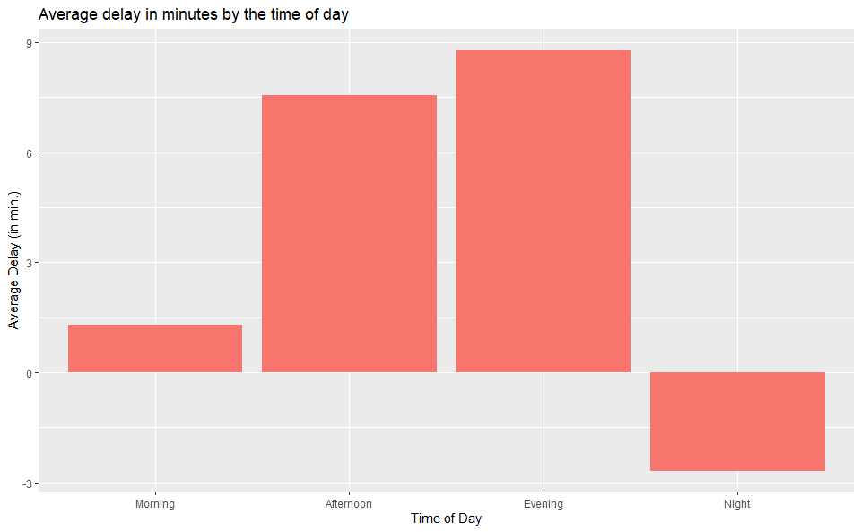

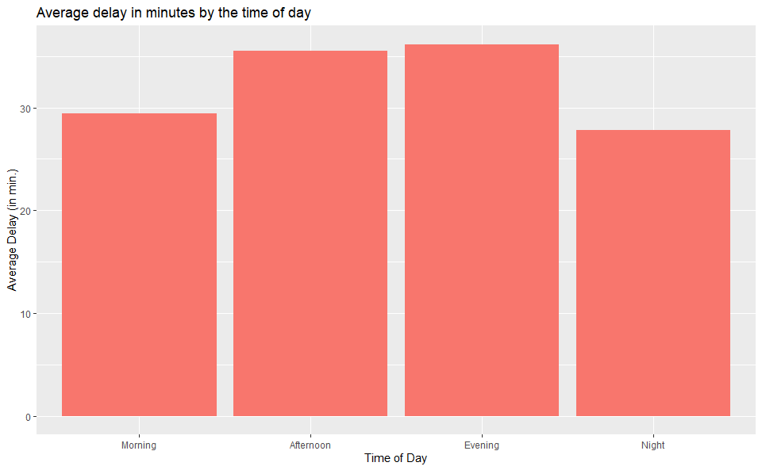

|  | hour | airport |
| --- | --- | --- |
| 1 | 0 | 1241 |
| 2 | 1 | 520 |
| 3 | 2 | 138 |
| 4 | 3 | 84 |
| 5 | 4 | 59 |
| 6 | 5 | 4470 |
| 7 | 6 | 18612 |
| 8 | 7 | 22684 |
| 9 | 8 | 26609 |
| 10 | 9 | 27104 |

[output cut: 14 more lines]

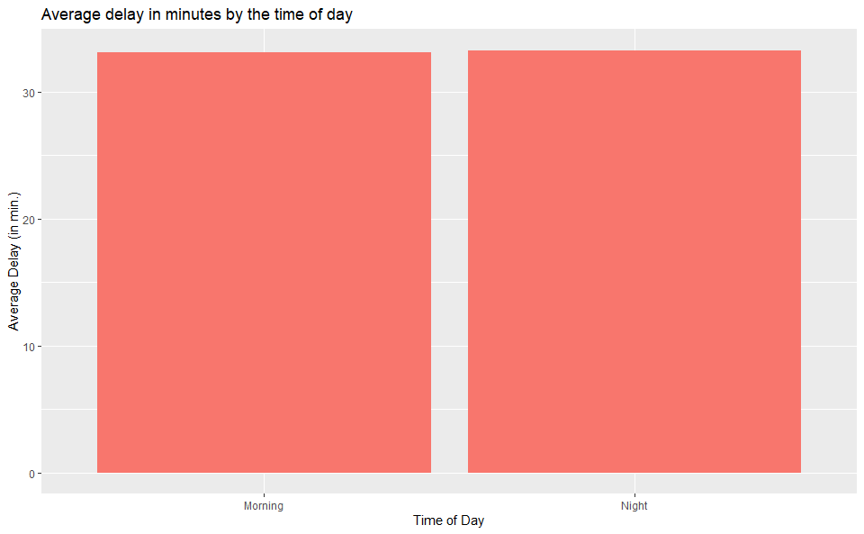

|  | hour | delay |
| --- | --- | --- |
| 1 | 0 | 0.8087424 |
| 2 | 1 | 3.8876449 |
| 3 | 2 | 1.8163413 |
| 4 | 3 | 1.7288136 |
| 5 | 4 | 3.6977186 |
| 6 | 5 | -3.7774175 |
| 7 | 6 | -2.6064094 |
| 8 | 7 | -1.5025469 |
| 9 | 8 | -0.1936355 |
| 10 | 9 | 0.9663874 |

[output cut: 14 more lines]

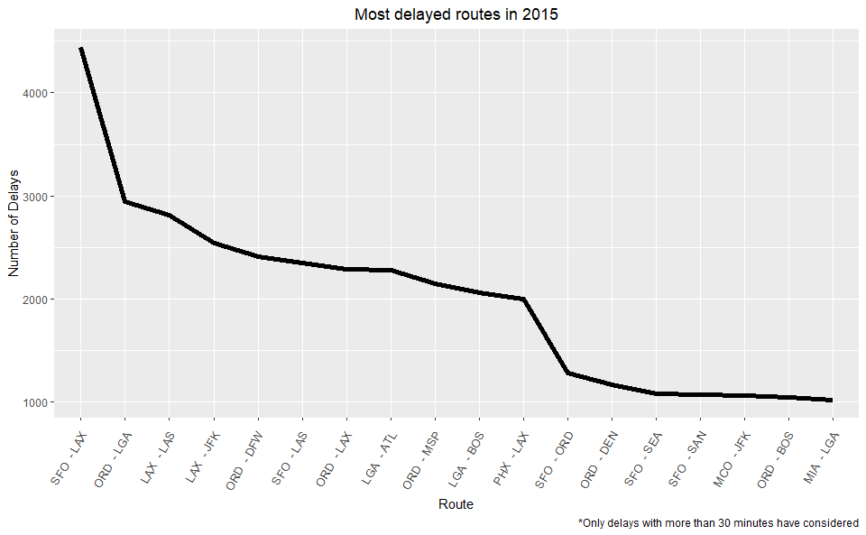

```r
dbGetQuery(con, "SELECT MAX(route) AS route, delay_num/total_flights FROM
    ((SELECT route, SUM(delays) AS delay_num FROM
        ((SELECT CONCAT(origin_airport,'- ',  destination_airport) AS route, COUNT(flight_number) AS delays FROM flights
          WHERE arrival_delay > 30
          GROUP BY route
          ORDER BY delays DESC
          LIMIT 30)
            UNION ALL
    (SELECT CONCAT(destination_airport,'- ',  origin_airport) AS route, COUNT(flight_number) AS delays FROM flights
          WHERE arrival_delay > 30
          GROUP BY route
          ORDER BY delays DESC
          LIMIT 30)) d
    GROUP BY route)
    UNION ALL
    (SELECT route, SUM(delays) AS total_flights FROM
        ((SELECT CONCAT(origin_airport,'- ',  destination_airport) AS route, COUNT(flight_number) AS delays FROM flights
          GROUP BY route
          ORDER BY delays DESC
          LIMIT 30)
            UNION ALL
    (SELECT CONCAT(destination_airport,'- ',  origin_airport) AS route, COUNT(flight_number) AS delays FROM flights
          GROUP BY route
          ORDER BY delays DESC
          LIMIT 30)) d
    GROUP BY route)) as k
  GROUP BY delay_num
  ORDER BY delay_num DESC
  ")
```

[output not shown]

```r
head(flights)

# taxi <- dbGetQuery(con, "WITH origin AS (
#   SELECT origin_airport AS airport, ROUND(AVG(taxi_out),2) AS avg_taxi_out
#   FROM flights
#   INNER JOIN airports
#   ON origin_airport = iata_code
#   GROUP BY origin_airport
# ),
# destination AS (
#   SELECT destination_airport AS airport, ROUND(AVG(taxi_in),2) AS avg_taxi_in
#   FROM flights
#   INNER JOIN airports
#   ON destination_airport = iata_code
#   GROUP BY destination_airport)
# SELECT iata_code AS airport_name, AVG(avg_taxi_out, avg_taxi,in)
# FROM airports
# INNER JOIN origin
# ON iata_code=origin_airport
# INNER JOIN destination
# ON iata_code = destination_airport
# GROUP BY airport_name
# LIMIT 30;")
# taxi
```

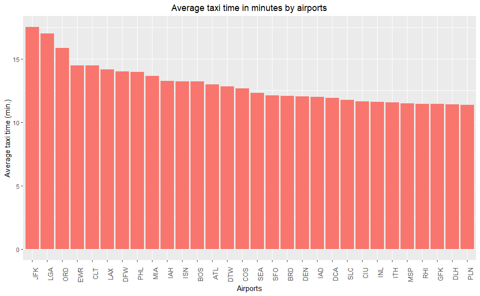

Taxi means the time that passed while taking position along the ground before the plane take-off or after landing. Taxi time could be depend on vary such as; volume, distance of the landing field so on. According to the graph, the top three airports, JFK, LGA and ORD are clearly separated from the others. While the general average taxi time is around 13 minutes, it takes more than 15 minutes for those 3 airports.

- Delays mostly occurs between San Francisco International Airport (SFO) and Los Angles International Airport (LAX) which normally can be considered as a close ranged flight (takes approximately 1 hour and 20 minutes).
- Delays take longer time in average at the evenings compared to the rest of the day.
- Planes need more taxi time at the John F. Kennedy International Airport (NY), LaGuardia International Airport (NY) and O’Hare International Airport (IL).

Delay time could be considered as one of the biggest issues in aviation. It can be affected by a lot of variable such as; distance, taxi time, weather, volume, location of the airport and so on. Therefore it is not easy to avoid at all but might be reduced by the joint R&D projects that conducted by airlines and airport management.